# Actividad 2 - Analítica descriptiva e inferencial

Jorge Alonso Hernández

1 de December, 2021

# 1 Lectura del fichero y preparación de los datos

Se realiza la carga de las librerías necesarias.

```r
if (!require('nortest')) install.packages('nortest'); library('nortest')
if (!require('ggplot2')) install.packages('ggplot2'); library('ggplot2')
```

Para iniciar la carga del archivo primero revisamos el documento facilitado. Generaremos una variable ala que denominaremos ruta_csv que almacenará la ruta de nuestro fichero, la cual obtenemos con la función:

```
file.choose()
```

Una vez tenemos la ruta del fichero realizamos la carga de los datos:

```r
ruta_csv <- "C:\\Users\\Jorge\\Documents\\Rstudio Workspace\\Estadística Avanzada\\Actividad 2\\train_clean2.csv"
claim <- read.csv(ruta_csv,na.strings="NA")

sapply(claim,class)
```

```
##                  X        ClaimNumber DateTimeOfAccident       DateReported
##          "integer"        "character"        "character"        "character"
##                Age             Gender      MaritalStatus  DependentChildren
##          "integer"        "character"        "character"          "integer"
##    DependentsOther        WeeklyWages   PartTimeFullTime          HoursWeek
##          "integer"          "numeric"        "character"          "numeric"
##           DaysWeek   ClaimDescription            IniCost            UltCost
##          "integer"        "character"          "integer"          "integer"
##               Time
##          "integer"
```

Podemos observar los tipos de datos con los que se han cargado cada una de las variables , y vemos que estos son correctos. Mostramos ahora una muestra de los datos para comprobar que la carga se ha realizado correctamente.

```r
head(claim)
```

```
##   X ClaimNumber   DateTimeOfAccident         DateReported Age Gender
## 1 1   WC8285054 2002-04-09T07:00:00Z 2002-07-05T00:00:00Z  48      M
## 2 2   WC6982224 1999-01-07T11:00:00Z 1999-01-20T00:00:00Z  43      F
## 3 3   WC5481426 1996-03-25T00:00:00Z 1996-04-14T00:00:00Z  30      M
## 4 4   WC9775968 2005-06-22T13:00:00Z 2005-07-22T00:00:00Z  41      M
## 5 5   WC2634037 1990-08-29T08:00:00Z 1990-09-27T00:00:00Z  36      M
## 6 6   WC6828422 1999-06-21T11:00:00Z 1999-09-09T00:00:00Z  50      M
##   MaritalStatus DependentChildren DependentsOther WeeklyWages PartTimeFullTime
## 1             M                 0               0      500.00                F
## 2             M                 0               0      509.34                F
## 3             M                 0               0      709.10                F
## 4             M                 0               0      555.46                F
## 5             M                 0               0      377.10                F
## 6             M                 0               0      200.00                F
##   HoursWeek DaysWeek
```

[output cut: 20 more lines]

# 2 Coste de los siniestros

## 2.1 Análisis visual

Para realizar el análisis visual primero visualizaremos el diagrama de caja de la variable “UltCost”

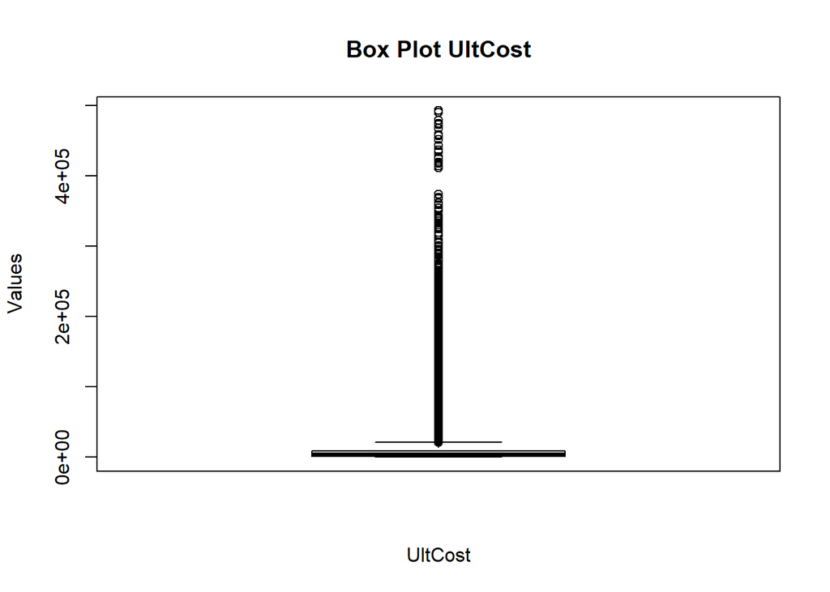

```r
boxplot(claim$UltCost, main="Box Plot UltCost", col="gray", xlab = "UltCost", ylab = "Values")
```

Ahora mostramos el diagrama de cajas de la variable “UltCost” a escala logarítmica:

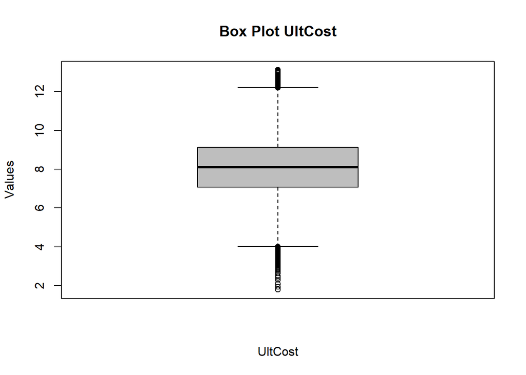

```r
boxplot(log(claim$UltCost), main="Box Plot UltCost", col="gray", xlab = "UltCost", ylab = "Values")
```

## 2.2 Comprobación de normalidad

Mostramos la distribución de los datos de la variable UltCost

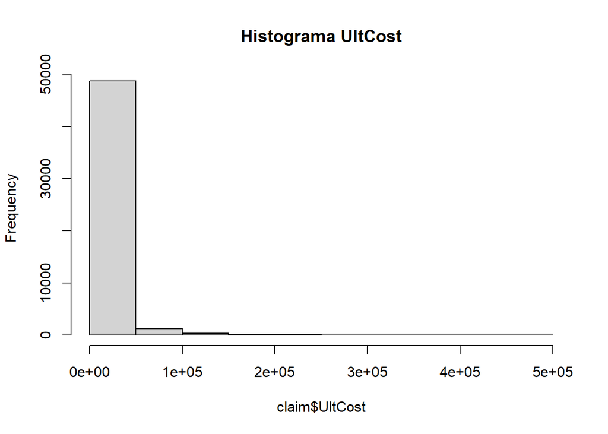

```r
hist(claim$UltCost, main="Histograma UltCost")
```

Nos encontramos con una asimetría a la derecha en los datos. Aplicamos el contraste de normalidad de Lilliefors para comprobar la normalidad de la distribución de los datos.

```r
lillie.test(claim$UltCost)
```

```
##
##  Lilliefors (Kolmogorov-Smirnov) normality test
##
## data:  claim$UltCost
## D = 0.33597, p-value < 2.2e-16
```

Como podemos comprobar dado que el p valor es inferior a 0.05 no nos encontramos ante una distribución normal de los datos.

Realizamos el estudio para la escala logarítmica de la variable UltCost.

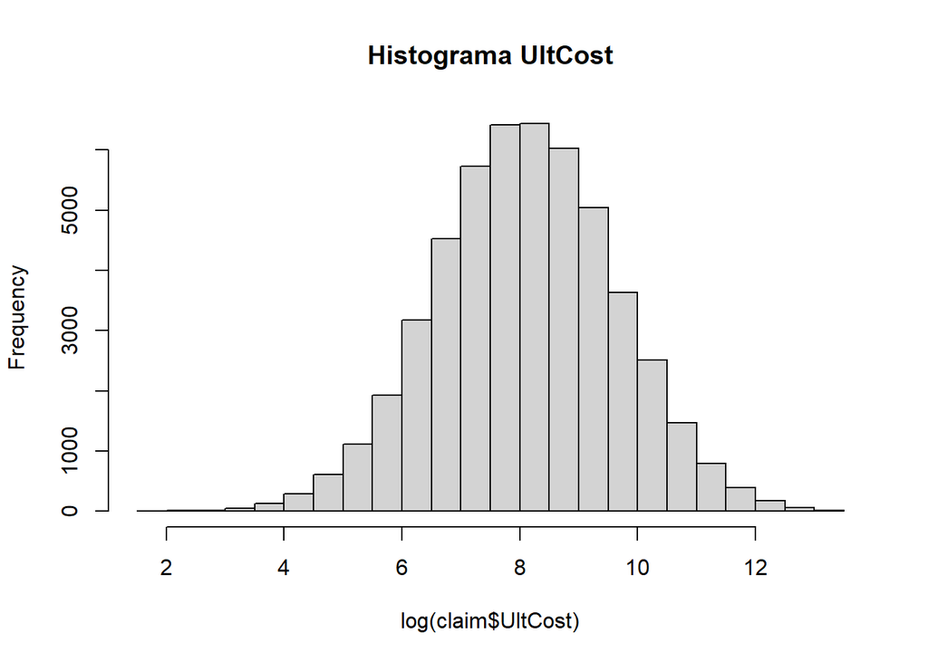

```r
hist(log(claim$UltCost), main="Histograma UltCost")
```

Como podemos observar en el gráfico nos encontramos ante una distribución simétrica

```r
lillie.test(log(claim$UltCost))
```

```
##
##  Lilliefors (Kolmogorov-Smirnov) normality test
##
## data:  log(claim$UltCost)
## D = 0.0029142, p-value = 0.375
```

En este caso observamos que el p valor es superior al 0.05 por lo que nos encontramos ante una distribución normal.

## 2.3 Intervalo de confianza de la media poblacional de la variable UltCost

Calculamos el intervalo de confianza al 95% de la media poblacional de la variable UltCost

```r
alfa <- 1-0.95
sd <- sd(claim$UltCost)
n <- nrow(claim)
SE <- sd / sqrt(n)
z <- qnorm(alfa/2, lower.tail=FALSE)
L <- mean(claim$UltCost) - z*SE
U <- mean(claim$UltCost) + z*SE
round(c(L,U),2)
```

```
## [1]  9938.86 10356.47
```

Podemos concluir con un 95% de confianza que el coste total pagado por siniestro se encuentra entre los valores 9938,86 y 10356.47

# 3 Coste inicial y final de los siniestros

## 3.3 Cálculos

Aplicamos los cálculos relativos al contraste de dos muestras emparejadas sobre la media

```r
alfa <- 1-0.95
d <- claim$IniCost- claim$UltCost
mean <- mean(d)
s <- sd(d)
n <- length(d)

tobs <- mean/(s/sqrt(n))
tcritL <- qt(alfa/2, df=n-1)
tcritU <- qt(1-alfa/2, df=n-1)
pvalue <- pt(tobs, lower.tail=FALSE, df=n-1)

c(mean,s,n, tobs)
```

```
## [1] -2159.35241 23334.31573 50526.00000   -20.80108
```

```r
c(tobs, tcritL,tcritU,pvalue)
```

```
## [1] -20.801081  -1.960011   1.960011   1.000000
```

Podemos ver que el valor observado es de -20.801, que el valor critico por la izquierda es de -1.96, el valor crítico por la derecha es de 1.96 y el p valor es de 1.

## 3.5 Comprobación

Realizamos la comprobación utilizando la función de R t.test

```r
t.test(claim$IniCost,claim$UltCost, paired=TRUE, alternative="greater")
```

```
##
##  Paired t-test
##
## data:  claim$IniCost and claim$UltCost
## t = -20.801, df = 50525, p-value = 1
## alternative hypothesis: true difference in means is greater than 0
## 95 percent confidence interval:
##  -2330.107       Inf
## sample estimates:
## mean of the differences
##               -2159.352
```

Podemos observar que la función acepta la hipótesis nula debido a que el p valor es superior al alfa definido de 0.05.

# 4 Diferencia de salario según género

## 4.1 Análisis visual

En primer lugar, para poder realizar el estudio obtenemos las muestras para mujeres y hombres de la variable WeeklyWages

```r
woman <- claim$WeeklyWages[claim$Gender == "F"]
man <- claim$WeeklyWages[claim$Gender == "M"]
```

Mostramos ahora los diagramas de cajas para los hombres y las mujeres de la variable WeeklyWages.

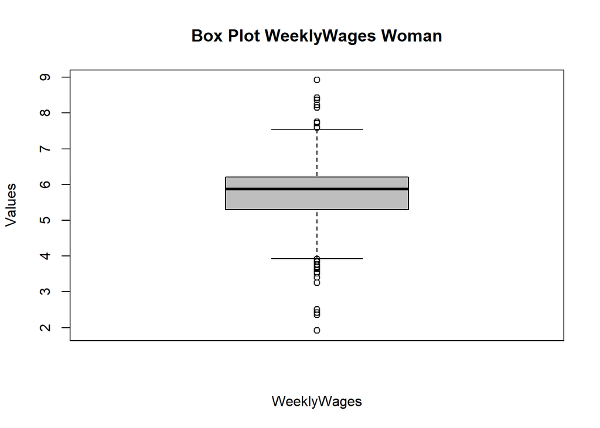

```r
boxplot(log(woman), main="Box Plot WeeklyWages Woman", col="gray", xlab = "WeeklyWages", ylab = "Values")
```

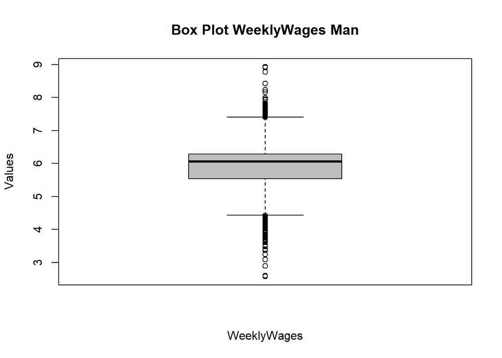

```r
boxplot(log(man), main="Box Plot WeeklyWages Man", col="gray", xlab = "WeeklyWages", ylab = "Values")
```

## 4.2 Interpretación

Podemos observar que en ambos casos la mayoría de datos para ambos sexos se localizan en el mismo intervalo, si podemos observar que para hombres existen más valores extremos que para las mujeres es decir que hay una mayor cantidad de salarios semanales que se encuentran por encima del límite superior y más valores inferiores al límite inferior en hombres que en mujeres.

## 4.3 Escribid la hipótesis nula y la alternativa

Definimos la hipótesis nula y alternativa:

- **Hipótesis nula:** el promedio del salario semanal de los hombres es igual al promedio salarial semanal de las mujeres
  $$H_O: µ_1 = µ_2$$
- **Hipótesis alternativa:** el promedio salarial semanal de los hombres es mayor que el promedio salarial semanal de las mujeres
  $$H_1: µ_1 > µ_2$$

## 4.4 Justificación del test a aplicar

Para este caso se aplicará un contraste de hipótesis sobre dos muestras, una para cada sexo, aplicado sobre la media del salario semanal y unilateralmente por la derecha dado que se pretende comprobar si el salario semanal de los hombres es mayor al de las mujeres.

## 4.5 Cálculos

Inicialmente realizamos el test de homoscedasticidad para comprobar si las varianzas son iguales o diferentes.

```r
alfa <- 1 - 0.95
H <- man
D <- woman
mean1 <- mean(H)
n1 <- length(H)
s1 <- sd(H)
mean2 <- mean(D)
n2 <- length(D)
s2 <- sd(D)
c(mean1, mean2, s1, s2, n1, n2)
```

```
## [1]   449.4311   381.3649   253.5549   213.6499 38904.0000 11620.0000
```

```r
fobs <- s1^2/s2^2
fcritL <- qf(alfa, df1=n1-1, df2=n2-2)
fcritU <- qf(1 - alfa, df1=n1-1, df2=n2-2)
pvalue <- min(pf(fobs, df1=n1-1, df2=n2-2, lower.tail=FALSE), pf(fobs, df1=n1-1, df2=n2-2))*2
c(fobs, fcritL, fcritU, pvalue)
```

```
## [1]  1.408441e+00  9.757980e-01  1.024996e+00 5.030028e-109
```

Dado que el p valor es inferior al alfa definido de 0.05 podemos asumir que las varianzas son diferente por lo tanto aplicaremos el estadístico del contraste de dos muestras sobre la media con varianzas desconocidas diferentes.

```r
alfa <- 1-0.95
dfMean = mean1 -mean2
v <- ((s1^2/n1)+(s2^2/n2))^2 / (((s2^2/n1)^2/(n1-1)) + ((s2^2/n2)^2/(n2-1)))

tobs <- dfMean/sqrt((s1^2/n1 + s2^2/n2))
tcrit <- qt(alfa, v)
pvalue <- pt(abs(tobs), df=v, lower.tail=FALSE)*2
c(tobs, tcrit, pvalue)
```

```
## [1]   2.881270e+01  -1.644920e+00  2.391262e-179
```

Podemos observar que el valor observado es 28.8127, el valor crítico es - 1.64492 y el p valor es de 2.391262e-179.

## 4.6 Conclusión

Dado que hemos obtenido un valor inferior al alfa definido de 0.05 podemos rechazar la hipótesis nula de que el promedio salarial de los hombres es igual al promedio salarial de las mujeres, por lo que se acepta la hipótesis alternativa de que el promedio salarial de los hombres es superior al de las mujeres.

## 4.7 Comprobación

Realizamos la comprobación del test de homoscedasticidad con la función de R var.test.

```r
var.test(H,D)
```

```
##
##  F test to compare two variances
##
## data:  H and D
## F = 1.4084, num df = 38903, denom df = 11619, p-value < 2.2e-16
## alternative hypothesis: true ratio of variances is not equal to 1
## 95 percent confidence interval:
##  1.367605 1.450156
## sample estimates:
## ratio of variances
##           1.408441
```

Podemos comprobar que el p valor devuelto por la función también es inferior a 0.05 por lo que son varianzas desconocidas diferentes.

Realizamos la comprobación del contraste de hipótesis empelando la función R t.test

```r
t.test(H,D)
```

```
##
##  Welch Two Sample t-test
##
## data:  H and D
## t = 28.813, df = 22274, p-value < 2.2e-16
## alternative hypothesis: true difference in means is not equal to 0
## 95 percent confidence interval:
##  63.43579 72.69661
## sample estimates:
## mean of x mean of y
##  449.4311  381.3649
```

Observamos de nuevo que el p valor devuelto es inferior al alfa definido por lo que comprobamos que se rechaza la hipótesis nula.

# 5 Salario semanal (II)

## 5.1 Escribid la hipótesis nula y la alternativa

Definimos la hipótesis nula y alternativa:

- **Hipótesis nula:** el promedio de la diferencia del salario semanal del hombre y la mujer es igual a 50.
  $$H_0: µ_d = 50$$
- **Hipótesis alternativa:** el promedio de la diferencia del salario semanal del hombre y la mujer es mayor que 50.
  $$H_1: µ_d > 50$$

## 5.3 Cálculos

Aplicamos los cálculos relativos al contraste de dos muestras emparejadas sobre la media.

```r
woman <- claim$WeeklyWages[claim$Gender == "F"]
man <- claim$WeeklyWages[claim$Gender == "M"]

mean <- mean(d)
s <- sd(d)
n<- length(d)

tobs <- (mean - 50)/(s/sqrt(n))
tcrit <- qt(alfa, df=n-1)
pvalue <- pt(tobs, lower.tail=FALSE, df=n-1)
c(tobs, tcrit, pvalue)
```

```
## [1] -21.282732  -1.644884   1.000000
```

## 5.5 Comprobación

Realizamos la comprobación utilizando la función de R t.test

```r
t.test(claim$IniCost,claim$UltCost, paired=TRUE, alternative="greater", mu=50)
```

```
##
##  Paired t-test
##
## data:  claim$IniCost and claim$UltCost
## t = -21.283, df = 50525, p-value = 1
## alternative hypothesis: true difference in means is greater than 50
## 95 percent confidence interval:
##  -2330.107       Inf
## sample estimates:
## mean of the differences
##               -2159.352
```

# 6 Diferencia de jornada según género

## 6.1 Análisis visual

Mostramos un diagrama de barras con las categorías de la variable PartTimeFullTime según el género.

```r
#Obtenemos las muestras para hombres y para mujeres
woman <- claim$PartTimeFullTime[claim$Gender == "F"]
man <- claim$PartTimeFullTime[claim$Gender == "M"]

#Calculamos la frecuencia de cada una de las variables y obtenemos sus porcentajes
df <- data.frame("Gender" = c("M", "M", "F", "F"), "PartTimeFullTime" = c("P", "F", "P", "F"))
df$freq <- c(length(man[man == "P"]), length(man[man == "F"]), length(woman[woman == "P"]),length(woman[woman == "F"]))
percentageMP <- (df$freq[df$Gender == "M" & df$PartTimeFullTime == "P"]/length(man)) * 100
percentageMF <- (df$freq[df$Gender == "M" & df$PartTimeFullTime == "F"]/length(man)) * 100
percentageFP <- (df$freq[df$Gender == "F" & df$PartTimeFullTime == "P"]/length(woman)) * 100
percentageFF <- (df$freq[df$Gender == "F" & df$PartTimeFullTime == "F"]/length(woman)) * 100
df$Percentage <- c(percentageMP, percentageMF, percentageFP, percentageFF)
```

Mostramos el diagrama de barras de los porcentajes.

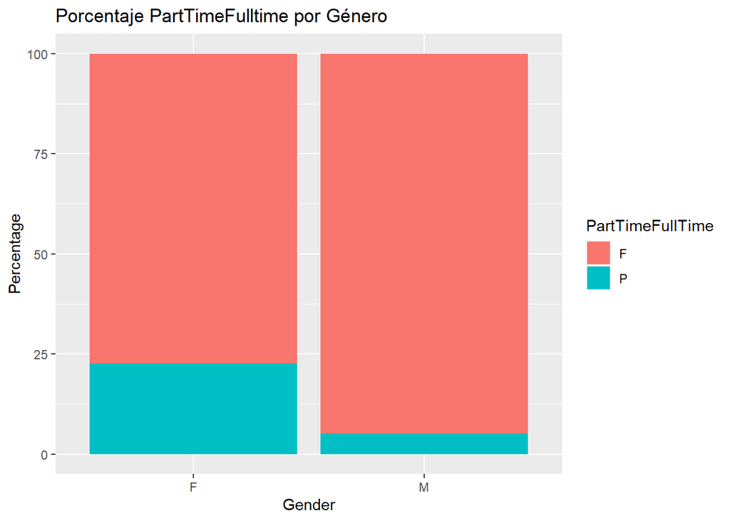

```r
ggplot(data=df, aes(x=Gender, fill=PartTimeFullTime, y=Percentage))+geom_col()+ggtitle("Porcentaje PartTimeFulltime por Género")
```

Mostramos también el gráfico con los datos totales.

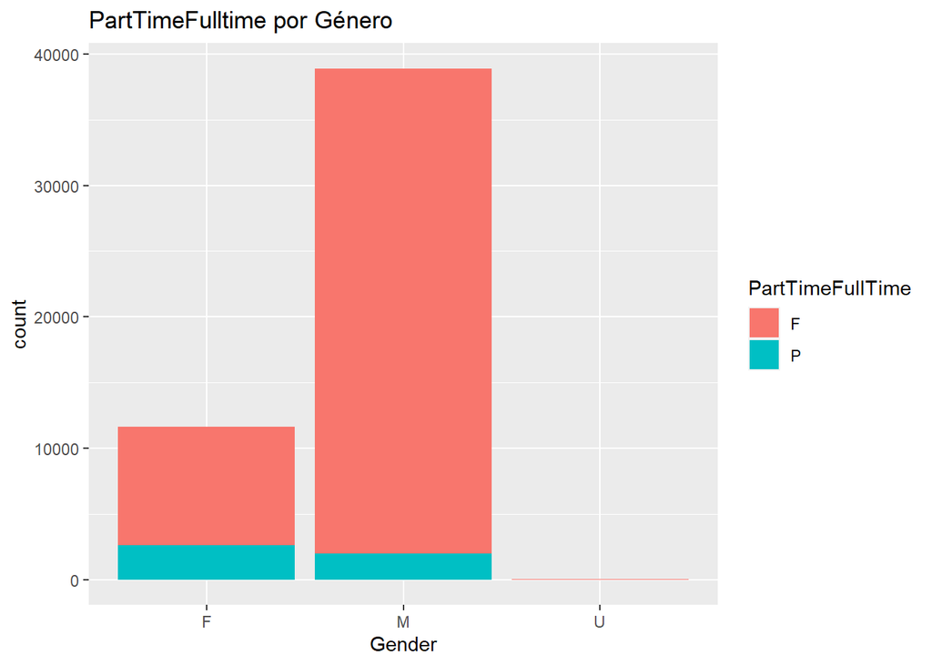

```r
ggplot(data=claim, aes(x=Gender,fill=PartTimeFullTime))+geom_bar()+ggtitle("PartTimeFulltime por Género")
```

## 6.2 Interpretación

De los gráficos obtenidos en el apartado anterior podemos observar que el porcentaje de hombres que trabajan a jornada completa es mayor al porcentaje de mujeres que trabaja a tiempo completo. También podemos observar que la muestra posee un mayor número de registros para hombres que para mujeres.

## 6.3 Hipótesis nula y alternativa

Definimos la hipótesis nula y alternativa:

- **Hipótesis nula:** la proporción de hombres que trabajan a tiempo completo es igual a la proporción de mujeres que trabajan a tiempo completo
  $$H_0: p_1 = p_2$$
- **Hipótesis alternativa:** la proporción de hombres que trabajan a tiempo completo es diferente a la proporción de mujeres que trabajan a tiempo completo
  $$H_1: p_1 ≠ p_2$$

## 6.4 Tipo de test

Para este caso se va a utilizar un contraste de hipótesis sobre dos muestras, una para hombres y otra para mujeres, aplicado sobre la proporción del tipo de jornada laboral. el contraste a aplicar es un contraste bilateral.

## 6.5 Cálculos

Aplicamos los cálculos relativos al contraste de la proporción de dos muestras.

```r
alfa <- 1-0.95
x1 <- man[man == 'F']
x2 <- woman[woman == 'F']

n1 <- length(man)
n2 <- length(woman)

p1 <- sum(length(x1))/n1
p2 <- sum(length(x2))/n2

c(p1,p2)
```

```
## [1] 0.9489513 0.7744406
```

```r
p <- (n1*p1 + n2*p2) / (n1+n2)
zobs <- (p1-p2)/(sqrt((p*(1-p))*(1/n1+1/n2)))
zcrit <- qnorm(alfa, lower.tail = FALSE)
pvalue <- pnorm(zobs, lower.tail=FALSE)

c(p1,p2)
```

```
## [1] 0.9489513 0.7744406
```

```r
c(zobs, zcrit,pvalue)
```

```
## [1] 57.342302  1.644854  0.000000
```

Podemos ver que el valor observado obtenido es 57.3423, el valor crítico es de 1.64485 y el p valor es de 0.

## 6.6 Conclusión

Con los resultados de los cálculos podemos rechazar la hipótesis nula debido a que el p-valor es inferior a nuestro alfa de 0.05, por lo que podemos concluir que la proporción de hombres que trabajan a tiempo completo es diferente a la proporción de mujeres que trabajan a tiempo completo con un nivel de confianza del 95%

## 6.7 Comprobación

Realizamos la comprobación utilizando la función de R prop.test.

```r
success <- c(p1*n1, p2*n2)
nn <- c(n1,n2)
prop.test(success, nn, alternative="greater", correct=FALSE)
```

```
##
##  2-sample test for equality of proportions without continuity
##  correction
##
## data:  success out of nn
## X-squared = 3288.1, df = 1, p-value < 2.2e-16
## alternative hypothesis: greater
## 95 percent confidence interval:
##  0.1678743 1.0000000
## sample estimates:
##    prop 1    prop 2
## 0.9489513 0.7744406
```

Podemos observar que la función también rechaza la hipótesis nula debido a que el p valor devuelto por esta es inferior al alfa de 0.05.

# 7 Salario por hora

## 7.1 Hipótesis nula y alternativa

Definimos la hipótesis nula y alternativa:

- **Hipótesis nula:** el promedio del salario por hora trabajada de los hombres es igual al promedio del salario por hora trabajada de las mujeres
  $$H_0: µ_1 = µ_2$$
- **Hipótesis alternativa:** el promedio del salario por hora trabajada de los hombres es mayor que el `promedio del salario por horas trabajadas de las mujeres
  $$H_1: µ_1 > µ_2$$

## 7.2 Tipo de test

Para este caso se va a utilizar un contraste de hipótesis sobre dos muestras, una correspondiente al salario por hora de los hombres y otra al salario por hora de las mujeres. Aplicaremos el contraste de hipótesis sobre la media del salario por hora. El contraste de hipótesis a utilizar es un contraste unilateral por la derecha.

## 7.3 Cálculos

Incialmente para poder aplicar el contraste de hipótesis debemos de calcular el salario por hora tanto para hombres como para mujeres

```r
#Obtenemos el salario por horas
claim$HourWages <- round((claim$WeeklyWages/claim$DaysWeek)/(claim$HoursWeek/claim$DaysWeek),2)
head(claim$HourWages)
```

```
## [1] 13.16 13.58 18.66 14.62  9.92  5.26
```

```r
#Obtenemos la muestra para hombres y mujeres
woman <- claim$HourWages[claim$Gender == "F"]
man <- claim$HourWages[claim$Gender == "M"]
```

Realizamos el test de homoscedasticidad para comprobar si las varianzas son iguales o diferentes

```r
alfa <- 1-0.95
H <- man
D <- woman
mean1 <- mean(H)
n1 <- length(H)
s1 <- sd(H)
mean2 <- mean(D)
n2 <- length(D)
s2 <- sd(D)
c(mean1, mean2, s1,s2,n1,n2)
```

```
## [1]    11.829776    11.763123     7.349630     9.303727 38904.000000
## [6] 11620.000000
```

```r
fobs <- s1^2/s2^2
fcrit <- qf(alfa, df1=n1-1, df2=n2-2)
pvalue <- min(pf(fobs, df1=n1-1, df2=n2-2, lower.tail=FALSE), pf(fobs, df1=n1-1, df2=n2-2))*2
c(fobs, fcrit, pvalue)
```

```
## [1]  6.240466e-01  9.757980e-01 3.524475e-236
```

Dado que el p valor es inferior al alfa que hemos definido de 0.05 podemos asumir que las varianzas son diferentes por lo tanto aplicaremos el estadístico del contraste de dos muestras sobre la media con varianzas desconocidas diferentes.

```r
alfa <- 1 - 0.95
dfMean <- mean1 - mean2
v <- ((s1^2/n1)+(s2^2/n2))^2 / (((s2^2/n1)^2/(n1-1)) + ((s2^2/n2)^2/(n2-1)))
tobs <- dfMean/sqrt((s1^2/n1 + s2^2/n2))
tcrit <- qt(alfa, v)
pvalue <- pt(abs(tobs), df=v, lower.tail=FALSE)*2
c(tobs, tcrit, pvalue)
```

```
## [1]  0.7090120 -1.6449493  0.4783274
```

Podemos observar que el valor observado es 0.709, el valor crítico es -1.6449 y el p valor es 0.4783274.

## 7.4 Conclusión

Podemos observar en los cálculos realizados en el apartado anterior que el p valor es mayor al alfa definido de 0.05 por lo que podemos aceptar la hipótesisis nula y podemos asumir que el promedio de salario por hora de los hombres es igual al promedio de salario por hora de las mujeres.

## 7.5 Comprobación

Realizamos la comprobación del test de homoscedasticidad con la función de R var.test.

```r
var.test(H,D)
```

```
##
##  F test to compare two variances
##
## data:  H and D
## F = 0.62405, num df = 38903, denom df = 11619, p-value < 2.2e-16
## alternative hypothesis: true ratio of variances is not equal to 1
## 95 percent confidence interval:
##  0.6059530 0.6425295
## sample estimates:
## ratio of variances
##          0.6240466
```

Podemos comprobar que el p valor devuelto por la función también es inferior a 0.05 por lo que son varianzas desconocids diferentes.

Realizamos la comprobaciópn del contraste de hipótesis empleando la función de R t.test.

```r
t.test(H,D)
```

```
##
##  Welch Two Sample t-test
##
## data:  H and D
## t = 0.70901, df = 16186, p-value = 0.4783
## alternative hypothesis: true difference in means is not equal to 0
## 95 percent confidence interval:
##  -0.1176142  0.2509208
## sample estimates:
## mean of x mean of y
##  11.82978  11.76312
```

Observamos que el p valor devuelto por la función es el mísmo que el obtenido mediante los cálculos por lo que comprobamos que se acepta la hipótesis nula definida.

# 8 Resumen ejecutivo

A lo largo de la actividad se han realizado los cálculos necesarios para dar respuesta a diversas preguntas que se han formulado, mediante contrastes de hipótesis. Las preguntas que han sido respondidas y sus correspondientes respuestas son:

- ¿Podemos aceptar que los hombres cobran más que las mujeres en promedio a la semana?

Con un 95% de confianza podemos aceptar que los hombres cobran más en promedio a la semana que las mujeres.

- ¿La proporción de personas que trabajan a tiempo completo es diferente para hombres que para mujeres?

Con un 95% de confianza podemos aceptar que la proporción de personas que trabajan a tiempo completo es diferente para hombres y mujeres.

- ¿Podemos afirmar que los hombres cobran más que las mujeres por hora trabajada?

Con un 95% de confianza podemos rechazar que los hombres cobran más que las mujeres por hora trabajada.